# High Note - Analyzing Freemium Subscription Service

```r
library(dplyr)
library(ggplot2)
library(gridExtra)
library(MatchIt)
library(caret)
library(e1071)
library(pROC)
library(psych)
```

```r
#Read data file into environment
df <- read.csv('HighNote Data.csv')
adopter_sum <- describe(subset(df,adopter==1))
non_adopter_sum <- describe(subset(df,adopter==0))
```

From the below summaries, we notice that adopters and non adopters do behave differently. Specifically there are difference in means in their demography, usage statistics, and peer circle. The subsequent analysis dives deep into each of these differences.

```r
adopter_sum
```

|  | vars | n | mean | sd | median | trimmed | mad | min | max | range | skew | kurtosis | se |
| --- | --- | --- | --- | --- | --- | --- | --- | --- | --- | --- | --- | --- | --- |
| ID | 1 | 3527 | 4.206400e+04 | 1.018302e+03 | 4.206400e+04 | 4.206400e+04 | 1307.653200 | 40301 | 43827 | 3526 | 0.00000000 | -1.20102075 | 1.714643e+01 |
| age | 2 | 3527 | 2.597987e+01 | 6.843597e+00 | 2.400000e+01 | 2.505243e+01 | 4.447800 | 8 | 73 | 65 | 1.68330111 | 4.38827324 | 1.152343e-01 |
| male | 3 | 3527 | 7.292316e-01 | 4.444197e-01 | 1.000000e+00 | 7.863974e-01 | 0.000000 | 0 | 1 | 1 | -1.03130738 | -0.93667042 | 7.483255e-03 |
| friend_cnt | 4 | 3527 | 3.973377e+01 | 1.172749e+02 | 1.600000e+01 | 2.369182e+01 | 17.791200 | 1 | 5089 | 5088 | 26.04316491 | 1013.78544994 | 1.974705e+00 |
| avg_friend_age | 5 | 3527 | 2.544131e+01 | 5.209021e+00 | 2.436000e+01 | 2.482676e+01 | 3.914064 | 12 | 62 | 50 | 1.68344068 | 5.05338242 | 8.771087e-02 |
| avg_friend_male | 6 | 3527 | 6.365983e-01 | 2.502875e-01 | 6.666667e-01 | 6.534577e-01 | 0.247100 | 0 | 1 | 1 | -0.54249275 | -0.04667754 | 4.214407e-03 |
| friend_country_cnt | 7 | 3527 | 7.188829e+00 | 8.859818e+00 | 4.000000e+00 | 5.357067e+00 | 4.447800 | 0 | 136 | 136 | 3.60961782 | 24.52926347 | 1.491839e-01 |
| subscriber_friend_cnt | 8 | 3527 | 1.636802e+00 | 5.849981e+00 | 0.000000e+00 | 8.402409e-01 | 0.000000 | 0 | 287 | 287 | 34.04550993 | 1609.51623495 | 9.850351e-02 |
| songsListened | 9 | 3527 | 3.375804e+04 | 4.359273e+04 | 2.090800e+04 | 2.581169e+04 | 23276.820000 | 0 | 817290 | 817290 | 4.71192298 | 46.63596085 | 7.340258e+02 |
| lovedTracks | 10 | 3527 | 2.643408e+02 | 4.914268e+02 | 1.080000e+02 | 1.616844e+02 | 140.847000 | 0 | 10220 | 10220 | 6.51951052 | 80.96130464 | 8.274773e+00 |
| posts | 11 | 3527 | 2.120045e+01 | 2.219934e+02 | 0.000000e+00 | 1.436415e+00 | 0.000000 | 0 | 8506 | 8506 | 26.52258090 | 852.38134353 | 3.737984e+00 |
| playlists | 12 | 3527 | 9.007655e-01 | 2.563392e+00 | 1.000000e+00 | 5.876727e-01 | 1.482600 | 0 | 118 | 118 | 28.84310504 | 1244.30554776 | 4.316306e-02 |
| shouts | 13 | 3527 | 9.943975e+01 | 1.156073e+03 | 9.000000e+00 | 2.388913e+01 | 11.860800 | 0 | 65872 | 65872 | 52.51753042 | 2969.08645004 | 1.946626e+01 |
| adopter | 14 | 3527 | 1.000000e+00 | 0.000000e+00 | 1.000000e+00 | 1.000000e+00 | 0.000000 | 1 | 1 | 0 | NaN | NaN | 0.000000e+00 |
| tenure | 15 | 3527 | 4.558322e+01 | 2.004376e+01 | 4.600000e+01 | 4.559830e+01 | 20.756400 | 0 | 111 | 111 | 0.01966554 | -0.62495167 | 3.375022e-01 |
| good_country | 16 | 3527 | 2.874965e-01 | 4.526592e-01 | 0.000000e+00 | 2.345023e-01 | 0.000000 | 0 | 1 | 1 | 0.93864568 | -1.11926140 | 7.621994e-03 |

```r
non_adopter_sum
```

|  | vars | n | mean | sd | median | trimmed | mad | min | max | range | skew | kurtosis | se |
| --- | --- | --- | --- | --- | --- | --- | --- | --- | --- | --- | --- | --- | --- |
| ID | 1 | 40300 | 2.015050e+04 | 1.163375e+04 | 2.015050e+04 | 2.015050e+04 | 14937.1950 | 1 | 40300 | 40299 | 0.00000000 | -1.2000893 | 5.795185e+01 |
| age | 2 | 40300 | 2.394844e+01 | 6.371831e+00 | 2.300000e+01 | 2.309355e+01 | 4.4478 | 8 | 79 | 71 | 1.96742309 | 6.7954029 | 3.174035e-02 |
| male | 3 | 40300 | 6.218610e-01 | 4.849286e-01 | 1.000000e+00 | 6.523263e-01 | 0.0000 | 0 | 1 | 1 | -0.50258131 | -1.7474554 | 2.415601e-03 |
| friend_cnt | 4 | 40300 | 1.849166e+01 | 5.748117e+01 | 7.000000e+00 | 1.028074e+01 | 7.4130 | 1 | 4957 | 4956 | 32.67366911 | 2087.4244081 | 2.863341e-01 |
| avg_friend_age | 5 | 40300 | 2.401142e+01 | 5.104109e+00 | 2.300000e+01 | 2.339978e+01 | 3.9536 | 8 | 77 | 69 | 1.84206182 | 7.1537073 | 2.542538e-02 |
| avg_friend_male | 6 | 40300 | 6.165888e-01 | 3.189849e-01 | 6.666667e-01 | 6.457360e-01 | 0.3530 | 0 | 1 | 1 | -0.51649618 | -0.7204039 | 1.588977e-03 |
| friend_country_cnt | 7 | 40300 | 3.957891e+00 | 5.764167e+00 | 2.000000e+00 | 2.662903e+00 | 1.4826 | 0 | 129 | 129 | 4.73934298 | 38.2904885 | 2.871336e-02 |
| subscriber_friend_cnt | 8 | 40300 | 4.174690e-01 | 2.418151e+00 | 0.000000e+00 | 1.255893e-01 | 0.0000 | 0 | 309 | 309 | 72.19357997 | 8024.6170660 | 1.204567e-02 |
| songsListened | 9 | 40300 | 1.758944e+04 | 2.841602e+04 | 7.440000e+03 | 1.181764e+04 | 10576.8684 | 0 | 1000000 | 1000000 | 6.04954176 | 105.8459637 | 1.415503e+02 |
| lovedTracks | 10 | 40300 | 8.682263e+01 | 2.635804e+02 | 1.400000e+01 | 3.635102e+01 | 20.7564 | 0 | 12522 | 12522 | 13.11545425 | 335.9317889 | 1.312988e+00 |
| posts | 11 | 40300 | 5.293002e+00 | 1.043094e+02 | 0.000000e+00 | 2.254342e-01 | 0.0000 | 0 | 12309 | 12309 | 73.91520131 | 7005.3350036 | 5.196023e-01 |
| playlists | 12 | 40300 | 5.492804e-01 | 1.071956e+00 | 0.000000e+00 | 4.463400e-01 | 0.0000 | 0 | 98 | 98 | 28.21141801 | 1945.2787423 | 5.339791e-03 |
| shouts | 13 | 40300 | 2.997266e+01 | 1.506898e+02 | 4.000000e+00 | 8.841563e+00 | 4.4478 | 0 | 7736 | 7736 | 22.53491092 | 779.1226978 | 7.506393e-01 |
| adopter | 14 | 40300 | 0.000000e+00 | 0.000000e+00 | 0.000000e+00 | 0.000000e+00 | 0.0000 | 0 | 0 | 0 | NaN | NaN | 0.000000e+00 |
| tenure | 15 | 40300 | 4.380993e+01 | 1.978887e+01 | 4.400000e+01 | 4.372413e+01 | 22.2390 | 1 | 111 | 110 | 0.04578935 | -0.6991943 | 9.857536e-02 |
| good_country | 16 | 40300 | 3.577916e-01 | 4.793563e-01 | 0.000000e+00 | 3.222395e-01 | 0.0000 | 0 | 1 | 1 | 0.59331611 | -1.6480169 | 2.387844e-03 |

# Understanding Demographic Composition of Adopters vs Non Adopters

### Key Findings

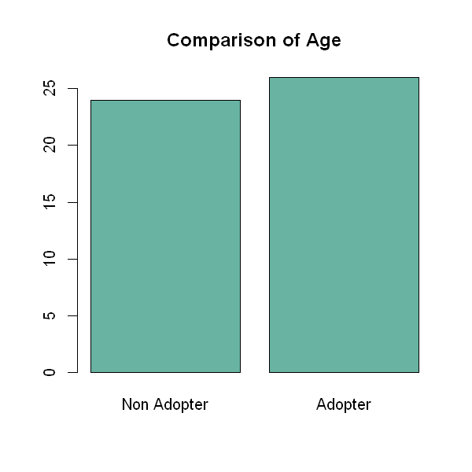

```r
#Comparing Mean age of Adopters vs Non-Adopters
options(repr.plot.width=5, repr.plot.height=5)
t_mean_age <- aggregate(age ~ adopter, df, mean)
barplot(height = t_mean_age$age, main="Comparison of Age", horiz=FALSE,names.arg=c("Non Adopter", "Adopter"),col = "#69b3a2")
```

| male | adopter | Freq | group_tot | gend_share |
| --- | --- | --- | --- | --- |
| 0 | 0 | 15239 | 16194 | 94.1 |
| 1 | 0 | 25061 | 27633 | 90.7 |
| 0 | 1 | 955 | 16194 | 5.9 |
| 1 | 1 | 2572 | 27633 | 9.3 |

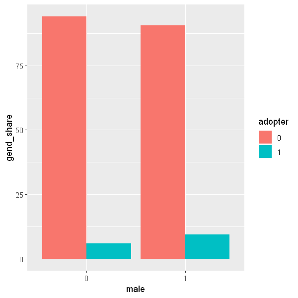

```r
#Comparing Gender Composition of Adopters vs Non Adopters
perc_comp <- as.data.frame(table(df$male, df$adopter))
names(perc_comp)<- c('male','adopter','Freq')
group <- perc_comp %>% group_by(male) %>% summarize(group_tot = sum(Freq)) %>% ungroup()
perc_comp$group_tot <- ifelse(perc_comp$male == group$male, group$group_tot,0)
perc_comp$gend_share <- round(perc_comp$Freq/perc_comp$group_tot,3)*100

ggplot(perc_comp, aes(fill=adopter, y=gend_share, x=male)) +
    geom_bar(position="dodge", stat="identity")
perc_comp
#% of Female adopters is 10% which is roughly double than female non adopters. % of Male adopters is slightly lower(~4% points) as compared to non adopters
```

# Analyzing effect of Peer Influence

### Key Findings

1. Adopters have a significantly higher circle of friends as compared to Non-Adopters
2. In continuation to the above point, even the number of subscriber friends is highest amongst adopters
3. It doesnt seem like the gender of friends has an effect on being a subscriber, it does seem like adopters have a slightly higher share of male friends

Based on the above findings, there exists a definite correlation between the social engagement of a user and his/her adoption rate

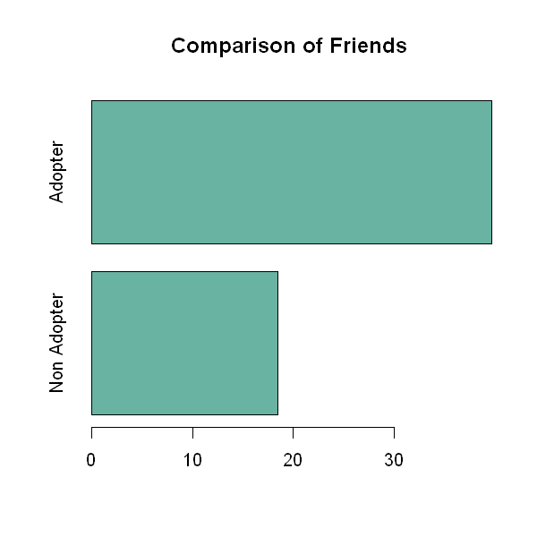

```r
#Understanding Social Circle of Adopters vs Non Adopters
t_mean_frnds <- aggregate(friend_cnt ~ adopter, df, mean)
barplot(height = t_mean_frnds$friend_cnt, main="Comparison of Friends", horiz=TRUE,names.arg=c("Non Adopter", "Adopter"),col="#69b3a2")
#Adopters have substantially higher number of friends compared to Non Adopters
```

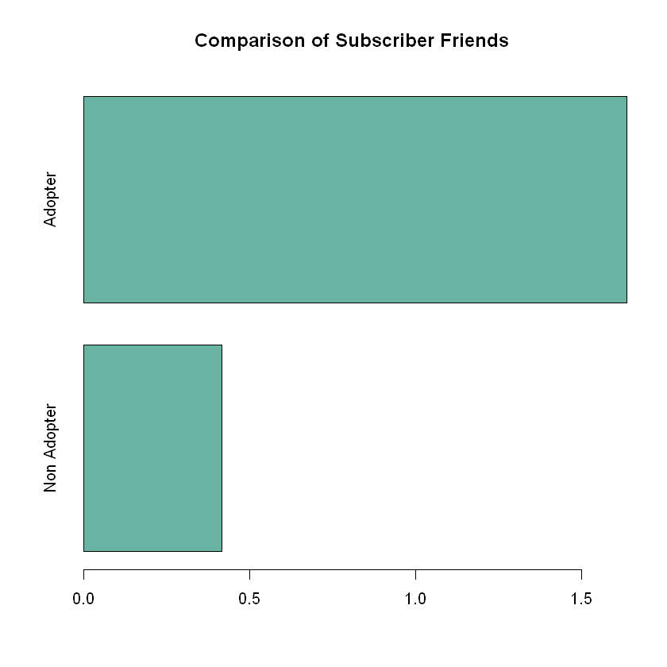

```r
#Understanding Social Circle of Adopters vs Non Adopters
t_mean_subfrnds <- aggregate(subscriber_friend_cnt ~ adopter, df, mean)
barplot(height = t_mean_subfrnds$subscriber_friend_cnt, main="Comparison of Subscriber Friends", horiz=TRUE,names.arg=c("Non Adopter", "Adopter"),col="#69b3a2")
#Non adopters not surprisingly have the lowest subscriber friends. This could means that peer circle can influence choice of adoption
```

| adopter | avg_friend_male |
| --- | --- |
| 0 | 0.6165888 |
| 1 | 0.6365983 |

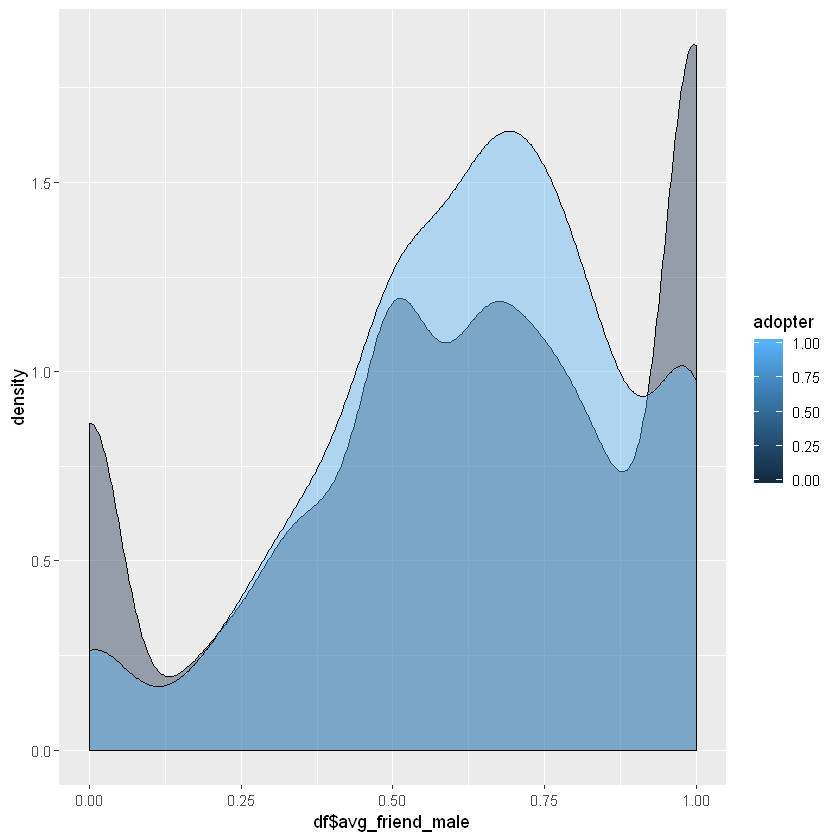

```r
#Understanding proportion of Male/Female friends
df_adopt <- subset(df,adopter==1)
df_nonadopt <- subset(df,adopter==0)

#Proportion of Male friends follows a similar distribution when comparing Adopters & Non Adopters.
t_mean_maleprop <- aggregate(avg_friend_male ~ adopter, df, mean)
t_mean_maleprop

ggplot(data=df, aes(x=df$avg_friend_male, group=adopter, fill=adopter)) +
    geom_density(adjust=1.5, alpha=.4)

#Adopters have higher density of Male friends as compared to Non Adopters
```

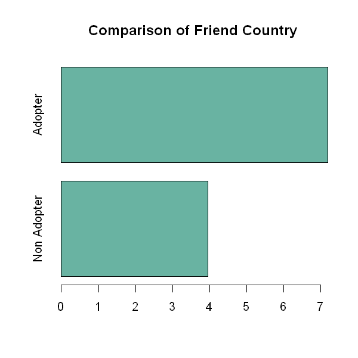

```r
#Understanding distribution of friends
t_mean_frnd_country <- aggregate(friend_country_cnt ~ adopter, df, mean)
barplot(height = t_mean_frnd_country$friend_country_cnt, main="Comparison of Friend Country", horiz=TRUE,names.arg=c("Non Adopter", "Adopter"),col="#69b3a2")
```

# Understanding effect of User Engagement

### Key Findings

1. Adopters have a higher number of songs listened to as compared to non adopters
2. Adopters are more likelier to indicate songs liked as compared to non adopters
3. Adopters have a higher number of posts as compared to non adopters
4. Adopters have a higher number of playlists as compared to non adopters
5. Adopters have a higher number of shouts as compared to non adopters
6. Suprisingly the difference between tenures of adopters & non adopters are comparable

Through all these graphs, we can conclude that users with a higher engagement are likelier to be adopters

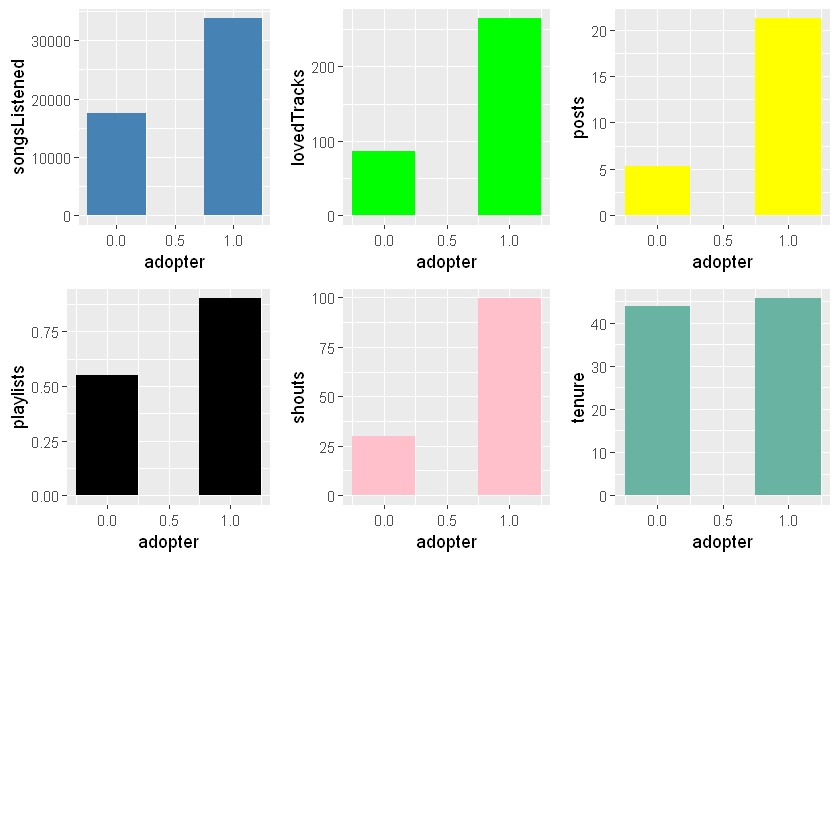

```r
t_mean_songsListened <- aggregate(songsListened ~ adopter, df, mean)
t_mean_lovedTracks <- aggregate(lovedTracks ~ adopter, df, mean)
t_mean_posts <- aggregate(posts ~ adopter, df, mean)
t_mean_playlists <- aggregate(playlists ~ adopter, df, mean)
t_mean_shouts <- aggregate(shouts ~ adopter, df, mean)
t_mean_tenure <- aggregate(tenure ~ adopter, df, mean)

p1 <- ggplot(data=t_mean_songsListened, aes(x=adopter, y=songsListened)) +
  geom_bar(stat="identity", width=0.5,fill="steelblue")

p2 <- ggplot(data=t_mean_lovedTracks, aes(x=adopter, y=lovedTracks)) +
  geom_bar(stat="identity", width=0.5,fill="green")

p3 <- ggplot(data=t_mean_posts, aes(x=adopter, y=posts)) +
  geom_bar(stat="identity", width=0.5,fill="yellow")

p4 <-ggplot(data=t_mean_playlists, aes(x=adopter, y=playlists)) +
  geom_bar(stat="identity", width=0.5,fill="black")

p5 <- ggplot(data=t_mean_shouts, aes(x=adopter, y=shouts)) +
  geom_bar(stat="identity", width=0.5,fill="pink")

p6 <- ggplot(data=t_mean_tenure, aes(x=adopter, y=tenure)) +
  geom_bar(stat="identity", width=0.5,fill="#69b3a2")

grid.arrange(p1, p2, p3,p4,p5,p6, ncol = 3,nrow=3)
#Adopters have a high tendency to be more socially engaged than compared to non adopters.
#Surprisngly Tenure does not differentiate an adopter from a non adopter
```

# Propensity Score Matching

```r
#Current Difference in Means between treatment and control
df_means <- subset(df,select = -ID)
df_means$Test <- ifelse(df$subscriber_friend_cnt>0,1,0)
df_means1 <- df_means %>% group_by(Test) %>% summarise(across(everything(), mean))
df_means1
#There is a large deviance in the observed means between the Adopter & Non-Adopter groups. Performing a T-Test shows that these means are significant as well
```

| Test | age | male | friend_cnt | avg_friend_age | avg_friend_male | friend_country_cnt | subscriber_friend_cnt | songsListened | lovedTracks | posts | playlists | shouts | adopter | tenure | good_country |
| --- | --- | --- | --- | --- | --- | --- | --- | --- | --- | --- | --- | --- | --- | --- | --- |
| 0 | 23.74756 | 0.6288378 | 10.43133 | 23.76137 | 0.6131124 | 2.725062 | 0.000000 | 14602.22 | 65.21365 | 2.543377 | 0.5294671 | 16.42304 | 0.05243501 | 43.20268 | 0.3546936 |
| 1 | 25.37321 | 0.6362618 | 54.02097 | 25.39043 | 0.6358077 | 9.385626 | 2.300417 | 33735.64 | 225.36465 | 20.522956 | 0.7440700 | 101.81951 | 0.17754250 | 46.54871 | 0.3432760 |

```r
with(df_means, t.test(age ~ Test))
with(df_means, t.test(male ~ Test))
with(df_means, t.test(friend_cnt ~ Test))
with(df_means, t.test(avg_friend_age ~ Test))
with(df_means, t.test(avg_friend_male ~ Test))
with(df_means, t.test(friend_country_cnt ~ Test))
with(df_means, t.test(songsListened ~ Test))
```

```
	Welch Two Sample t-test

data:  age by Test
t = -20.841, df = 14645, p-value < 2.2e-16
alternative hypothesis: true difference in means is not equal to 0
95 percent confidence interval:
 -1.778544 -1.472749
sample estimates:
mean in group 0 mean in group 1
       23.74756        25.37321
```

```
	Welch Two Sample t-test

data:  male by Test
t = -1.3459, df = 15986, p-value = 0.1784
alternative hypothesis: true difference in means is not equal to 0
95 percent confidence interval:
 -0.018236129  0.003388028
sample estimates:
mean in group 0 mean in group 1
      0.6288378       0.6362618
```

```
	Welch Two Sample t-test

data:  friend_cnt by Test
t = -33.707, df = 9903.1, p-value < 2.2e-16
alternative hypothesis: true difference in means is not equal to 0
95 percent confidence interval:
 -46.12459 -41.05469
sample estimates:
mean in group 0 mean in group 1
       10.43133        54.02097
```

```
	Welch Two Sample t-test

data:  avg_friend_age by Test
t = -27.658, df = 15667, p-value < 2.2e-16
alternative hypothesis: true difference in means is not equal to 0
95 percent confidence interval:
 -1.744514 -1.513611
sample estimates:
mean in group 0 mean in group 1
       23.76137        25.39043
```

```
	Welch Two Sample t-test

data:  avg_friend_male by Test
t = -7.7114, df = 23020, p-value = 1.294e-14
alternative hypothesis: true difference in means is not equal to 0
95 percent confidence interval:
 -0.02846397 -0.01692672
sample estimates:
mean in group 0 mean in group 1
      0.6131124       0.6358077
```

```
	Welch Two Sample t-test

data:  friend_country_cnt by Test
t = -65.05, df = 10372, p-value < 2.2e-16
alternative hypothesis: true difference in means is not equal to 0
95 percent confidence interval:
 -6.861271 -6.459857
sample estimates:
mean in group 0 mean in group 1
       2.725062        9.385626
```

```
	Welch Two Sample t-test

data:  songsListened by Test
t = -41.505, df = 11447, p-value < 2.2e-16
alternative hypothesis: true difference in means is not equal to 0
95 percent confidence interval:
 -20037.04 -18229.80
sample estimates:
mean in group 0 mean in group 1
       14602.22        33735.64
```

As we observed above, there is a large mismatch in the means between the groups selected for experiments. I will now perform PSM and then retest the means to conclude the matching process eliminated the difference in means. When I ran the Logistic Regression with all variables constant I got a converging error. I then realised that the data is extremely skewed and hence need to take a log transform.

```r
#Create Test/Control flag on the original df
df_psm <- df
df_psm$Test <- ifelse(df$subscriber_friend_cnt>0,1,0)
#head(df_psm)

#Create a logistic regression equation - this estimates the propensity of a customer belonging to treatment/control
psm <- glm(Test~.,family = binomial(), data = df_psm)
summary(psm)
#There is presence of outliers and hence our model is not able to distinguish between 0's & 1's
#Rerunning with log transforms
psm_log <- glm(Test ~log(age) + male +log(friend_cnt+1) + log(avg_friend_age+1)  + log(avg_friend_male+1) +
                       log(friend_country_cnt+1) + log(songsListened+1) + log(lovedTracks+1) + log(posts+1) +
                       log(playlists+1) + log(shouts+1) + log(tenure+1) + good_country, family = binomial(), data = df_psm)
summary(psm_log)

psm_df <- data.frame(pr_score = predict(psm_log, type = "response"),
                     Test = psm_log$model$Test)
```

```
Call:
glm(formula = Test ~ ., family = binomial(), data = df_psm)

Deviance Residuals:
       Min          1Q      Median          3Q         Max
-1.397e-05  -5.431e-06  -5.107e-06  -4.778e-06   3.865e-05

Coefficients:
                        Estimate Std. Error z value Pr(>|z|)
(Intercept)           -2.547e+01  3.632e+03  -0.007    0.994
ID                    -7.970e-07  5.700e-02   0.000    1.000
age                   -4.605e-03  1.439e+02   0.000    1.000
male                   1.759e-02  1.364e+03   0.000    1.000
friend_cnt            -6.852e-03  2.760e+01   0.000    1.000
avg_friend_age         2.199e-02  1.735e+02   0.000    1.000
avg_friend_male       -1.072e-03  2.202e+03   0.000    1.000
friend_country_cnt     4.777e-02  2.034e+02   0.000    1.000
subscriber_friend_cnt  4.820e+01  1.334e+03   0.036    0.971
songsListened          3.909e-06  2.397e-02   0.000    1.000
lovedTracks            1.173e-04  2.611e+00   0.000    1.000
posts                  1.483e-04  9.094e+00   0.000    1.000
playlists             -1.496e-02  6.307e+02   0.000    1.000
shouts                -1.436e-04  6.181e+00   0.000    1.000
adopter                1.317e-01  2.620e+03   0.000    1.000
tenure                -5.139e-04  3.549e+01   0.000    1.000
good_country          -3.972e-02  1.349e+03   0.000    1.000

(Dispersion parameter for binomial family taken to be 1)

    Null deviance: 4.6640e+04  on 43826  degrees of freedom
Residual deviance: 1.8429e-06  on 43810  degrees of freedom
AIC: 34

Number of Fisher Scoring iterations: 25
```

```
Call:
glm(formula = Test ~ log(age) + male + log(friend_cnt + 1) +
    log(avg_friend_age + 1) + log(avg_friend_male + 1) + log(friend_country_cnt +
    1) + log(songsListened + 1) + log(lovedTracks + 1) + log(posts +
    1) + log(playlists + 1) + log(shouts + 1) + log(tenure +
    1) + good_country, family = binomial(), data = df_psm)

Deviance Residuals:
    Min       1Q   Median       3Q      Max
-2.5576  -0.5682  -0.2997  -0.1170   3.3903

Coefficients:
                              Estimate Std. Error z value Pr(>|z|)
(Intercept)                 -17.758481   0.301395 -58.921  < 2e-16 ***
log(age)                      0.647953   0.095402   6.792 1.11e-11 ***
male                          0.078393   0.031386   2.498   0.0125 *
log(friend_cnt + 1)           1.078788   0.027146  39.740  < 2e-16 ***
log(avg_friend_age + 1)       3.486321   0.125283  27.828  < 2e-16 ***
log(avg_friend_male + 1)      0.381212   0.090651   4.205 2.61e-05 ***
log(friend_country_cnt + 1)   0.560058   0.032010  17.496  < 2e-16 ***
log(songsListened + 1)        0.051766   0.009154   5.655 1.56e-08 ***
log(lovedTracks + 1)          0.084539   0.007936  10.652  < 2e-16 ***
log(posts + 1)                0.079169   0.014703   5.385 7.26e-08 ***
log(playlists + 1)           -0.152139   0.035585  -4.275 1.91e-05 ***
log(shouts + 1)              -0.028970   0.013678  -2.118   0.0342 *
log(tenure + 1)              -0.367109   0.031064 -11.818  < 2e-16 ***
good_country                  0.059487   0.030370   1.959   0.0501 .
---
Signif. codes:  0 '***' 0.001 '**' 0.01 '*' 0.05 '.' 0.1 ' ' 1

(Dispersion parameter for binomial family taken to be 1)

    Null deviance: 46640  on 43826  degrees of freedom
Residual deviance: 31465  on 43813  degrees of freedom
AIC: 31493

Number of Fisher Scoring iterations: 6
```

[figure not shown]

```r
#Plot and verify the region of common support -This indicates there are enough data points to perfrom matched sample analysis
labs <- paste("Treatment Level:", c("Subscriber Friends > 0", "Subscriber Friends = 0"))
psm_df %>%
  mutate(Treatment = ifelse(Test == 1, labs[1], labs[2])) %>%
  ggplot(aes(x = pr_score)) +
  geom_histogram(color = "white",bins = 50) +
  facet_wrap(~Treatment) +
  xlab("Probability of receiving Treatment") +
  theme_bw()

#Looks like there are enough data points across all probability levels to perform a matched sample analysis
```

```r
#To create matched samples, we use the Matchit Function which estimated propensity score in the background and matches
#based on a specified algorithm. Here we match samples based on K-Nearest Neighbours
match <- matchit(Test ~log(age) + male +log(friend_cnt+1) + log(avg_friend_age+1)  + log(avg_friend_male+1) +
                       log(friend_country_cnt+1) + log(songsListened+1) + log(lovedTracks+1) + log(posts+1) +
                       log(playlists+1) + log(shouts+1) + log(tenure+1) + good_country,method = "nearest", data = df_psm)
summary(match)
match_data <- match.data(match)
#By looking at the output we see that there is a significnat improvement in the means after matching.
```

```
Call:
matchit(formula = Test ~ log(age) + male + log(friend_cnt + 1) +
    log(avg_friend_age + 1) + log(avg_friend_male + 1) + log(friend_country_cnt +
    1) + log(songsListened + 1) + log(lovedTracks + 1) + log(posts +
    1) + log(playlists + 1) + log(shouts + 1) + log(tenure +
    1) + good_country, data = df_psm, method = "nearest")

Summary of Balance for All Data:
                            Means Treated Means Control Std. Mean Diff.
distance                           0.4982        0.1450          1.2563
log(age)                           3.2014        3.1389          0.2532
male                               0.6363        0.6288          0.0154
log(friend_cnt + 1)                3.3261        1.9362          1.2499
log(avg_friend_age + 1)            3.2562        3.1912          0.3636
log(avg_friend_male + 1)           0.4814        0.4540          0.1829
log(friend_country_cnt + 1)        1.9993        1.1226          1.0812
log(songsListened + 1)             9.6020        7.9441          0.9450
log(lovedTracks + 1)               3.9582        2.4466          0.7383
log(posts + 1)                     0.8391        0.2865          0.4065
log(playlists + 1)                 0.4130        0.3364          0.1660
log(shouts + 1)                    3.0357        1.7159          0.7816
log(tenure + 1)                    3.7453        3.6546          0.1702
good_country                       0.3433        0.3547         -0.0240
                            Var. Ratio eCDF Mean eCDF Max
distance                        2.7957    0.3640   0.5613
log(age)                        1.1412    0.0240   0.1156
male                                 .    0.0074   0.0074
log(friend_cnt + 1)             1.3797    0.0851   0.4986
log(avg_friend_age + 1)         0.9353    0.1066   0.1802
log(avg_friend_male + 1)        0.4365    0.0847   0.1925
log(friend_country_cnt + 1)     2.1284    0.0799   0.4841
log(songsListened + 1)          0.4221    0.2273   0.3159
log(lovedTracks + 1)            1.0714    0.0893   0.3150
log(posts + 1)                  3.1830    0.0213   0.2267
log(playlists + 1)              1.3712    0.0058   0.0629
log(shouts + 1)                 1.8567    0.0677   0.3662
log(tenure + 1)                 0.8588    0.0310   0.0649
good_country                         .    0.0114   0.0114


```

[output cut: 40 more lines]

```
log(friend_country_cnt + 1)            58.9       32.1      39.0     58.3
log(songsListened + 1)                 85.7       99.5      77.8     76.6
log(lovedTracks + 1)                   71.6      -80.9      46.9     63.4
log(posts + 1)                         53.9       59.2      35.2     65.7
log(playlists + 1)                     69.0       31.3      48.3     61.8
log(shouts + 1)                        61.3       47.2      35.4     63.4
log(tenure + 1)                        85.6       59.9      87.6     78.7
good_country                           51.9          .      51.9     51.9

Sample Sizes:
          Control Treated
All         34004    9823
Matched      9823    9823
Unmatched   24181       0
Discarded       0       0
```

```r
with(match_data, t.test(age ~ Test))
with(match_data, t.test(male ~ Test))
with(match_data, t.test(friend_cnt ~ Test))
with(match_data, t.test(avg_friend_age ~ Test))
with(match_data, t.test(avg_friend_male ~ Test))
with(match_data, t.test(friend_country_cnt ~ Test))
with(match_data, t.test(songsListened ~ Test))
```

```
	Welch Two Sample t-test

data:  age by Test
t = -3.2394, df = 19644, p-value = 0.0012
alternative hypothesis: true difference in means is not equal to 0
95 percent confidence interval:
 -0.5178132 -0.1274072
sample estimates:
mean in group 0 mean in group 1
       25.05060        25.37321
```

```
	Welch Two Sample t-test

data:  male by Test
t = 0.92119, df = 19644, p-value = 0.357
alternative hypothesis: true difference in means is not equal to 0
95 percent confidence interval:
 -0.007118252  0.019741687
sample estimates:
mean in group 0 mean in group 1
      0.6425736       0.6362618
```

```
	Welch Two Sample t-test

data:  friend_cnt by Test
t = -23.39, df = 10436, p-value < 2.2e-16
alternative hypothesis: true difference in means is not equal to 0
95 percent confidence interval:
 -33.22345 -28.08551
sample estimates:
mean in group 0 mean in group 1
       23.36649        54.02097
```

```
	Welch Two Sample t-test

data:  avg_friend_age by Test
t = -0.084544, df = 19180, p-value = 0.9326
alternative hypothesis: true difference in means is not equal to 0
95 percent confidence interval:
 -0.1640151  0.1504513
sample estimates:
mean in group 0 mean in group 1
       25.38365        25.39043
```

```
	Welch Two Sample t-test

data:  avg_friend_male by Test
t = 0.19617, df = 19610, p-value = 0.8445
alternative hypothesis: true difference in means is not equal to 0
95 percent confidence interval:
 -0.005907321  0.007221277
sample estimates:
mean in group 0 mean in group 1
      0.6364647       0.6358077
```

```
	Welch Two Sample t-test

data:  friend_country_cnt by Test
t = -36.731, df = 13668, p-value < 2.2e-16
alternative hypothesis: true difference in means is not equal to 0
95 percent confidence interval:
 -4.287774 -3.853324
sample estimates:
mean in group 0 mean in group 1
       5.315077        9.385626
```

```
	Welch Two Sample t-test

data:  songsListened by Test
t = -13.34, df = 17584, p-value < 2.2e-16
alternative hypothesis: true difference in means is not equal to 0
95 percent confidence interval:
 -8282.139 -6160.025
sample estimates:
mean in group 0 mean in group 1
       26514.56        33735.64
```

```r
test <- subset(match_data,Test==1,select = adopter)
cont <- subset(match_data,Test==0,select = adopter)
t.test(test,cont)
#Treatment has a higher mean as compared to control, and based on the T-Test we can conclude that this difference is significant
```

```
	Welch Two Sample t-test

data:  test and cont
t = 17.858, df = 18260, p-value < 2.2e-16
alternative hypothesis: true difference in means is not equal to 0
95 percent confidence interval:
 0.07676179 0.09569061
sample estimates:
mean of x mean of y
0.1775425 0.0913163
```